# Data imports and preparation

We begin by importing necessary libraries and loading our gene expression dataset.

```python
import numpy as np
import pandas as pd
import matplotlib.pyplot as plt
import seaborn as sns
from scipy.stats import spearmanr
from sklearn.model_selection import train_test_split
from sklearn.metrics import roc_curve, auc
import warnings
warnings.filterwarnings('ignore')
```

```python
data= pd.read_csv('Final_mRNA_data.csv', index_col='Hugo_Symbol')
```

```python
data.head()
```

| Hugo_Symbol | TCGA-CA-6719-01 | TCGA-A8-A08R-01 | TCGA-AA-3952-01 | TCGA-EW-A1PH-01 | TCGA-86-6562-01 | TCGA-EE-A2GT-06 | TCGA-DJ-A13L-01 | TCGA-AR-A2LQ-01 | TCGA-OR-A5JG-01 | TCGA-EW-A1J2-01 | ... | TCGA-A2-A0EO-01 | TCGA-AA-A00E-01 | TCGA-D3-A2JK-06 | TCGA-DA-A1I8-06 | TCGA-05-5429-01 | TCGA-ER-A19G-06 | TCGA-BJ-A290-01 | TCGA-EM-A1YE-01 | TCGA-61-1918-01 | TCGA-49-4486-01 |
| --- | --- | --- | --- | --- | --- | --- | --- | --- | --- | --- | --- | --- | --- | --- | --- | --- | --- | --- | --- | --- | --- |
| A1BG | 10.9597 | 46.2179 | 37.086194 | 50.9582 | 166.410 | 199.2860 | 258.7500 | 144.0850 | 41.0856 | 96.6819 | ... | 78.5151 | 15.201932 | 581.3950 | 293.8760 | 93.5808 | 128.7470 | 94.6649 | 28.4374 | 145.652528 | 333.471 |
| A1CF | 123.3190 | 0.0000 | 126.861493 | 0.0000 | 0.000 | 0.0000 | 0.0000 | 0.0000 | 0.0000 | 0.2511 | ... | 0.0000 | 50.543546 | 0.0000 | 0.0000 | 99.7680 | 0.0000 | 0.0000 | 0.0000 | -0.269975 | 0.000 |
| A2BP1 | 1.8544 | 0.0000 | 0.357836 | 0.0000 | 0.000 | 0.0000 | 1.0714 | 1.8721 | 26.8709 | 0.2511 | ... | 0.0000 | -0.330564 | 0.0000 | 0.9315 | 0.0000 | 0.0000 | 973.4540 | 7.2360 | -0.157383 | 0.000 |
| A2LD1 | 195.8140 | 89.4370 | 159.156903 | 115.0650 | 172.376 | 31.4772 | 116.7890 | 108.2490 | 113.6590 | 76.3191 | ... | 74.1643 | 156.575287 | 85.3101 | 68.2543 | 224.2310 | 65.9846 | 101.5090 | 180.0850 | 96.691951 | 187.338 |
| A2M | 9242.9300 | 12307.8000 | 4722.103840 | 31343.6000 | 19967.300 | 9962.0600 | 8756.7400 | 37112.1000 | 8002.4900 | 26528.2000 | ... | 19807.2000 | 3541.251685 | 11302.3000 | 39563.4000 | 8091.1400 | 14534.1000 | 13352.2000 | 10153.8000 | 4885.124782 | 7331.550 |

5 rows × 3529 columns

We transpose the data to have samples as rows and genes as columns, which is the standard format for machine learning applications:

```python
X = data.T
```

```python
X.head()
```

| Hugo_Symbol | A1BG | A1CF | A2BP1 | A2LD1 | A2M | A2M-AS1 | A2ML1 | A4GALT | AAAS | AACS | ... | ZWINT | ZXDA | ZXDB | ZXDC | ZYG11A | ZYG11B | ZYX | ZZEF1 | ZZZ3 | psiTPTE22 |
| --- | --- | --- | --- | --- | --- | --- | --- | --- | --- | --- | --- | --- | --- | --- | --- | --- | --- | --- | --- | --- | --- |
| TCGA-CA-6719-01 | 10.959700 | 123.319000 | 1.854400 | 195.814000 | 9242.93000 | 9.276800 | 0.000000 | 217.895000 | 853.964000 | 556.328000 | ... | 525.267000 | 85.303700 | 646.732000 | 1068.150000 | 0.927200 | 853.037000 | 4807.140000 | 1540.100000 | 788.132000 | 22.716700 |
| TCGA-A8-A08R-01 | 46.217900 | 0.000000 | 0.000000 | 89.437000 | 12307.80000 | 19.354300 | 614.443000 | 370.257000 | 630.355000 | 462.974000 | ... | 543.758000 | 40.697700 | 335.067000 | 868.727000 | 83.537300 | 864.749000 | 6249.690000 | 1729.500000 | 804.468000 | 17.135900 |
| TCGA-AA-3952-01 | 37.086194 | 126.861493 | 0.357836 | 159.156903 | 4722.10384 | 30.052595 | 0.357854 | 142.902973 | 948.483572 | 1343.971965 | ... | 974.481502 | 49.494578 | 475.349048 | 710.985881 | 0.202985 | 640.782046 | 4247.792348 | 395.294614 | 436.407181 | 61.402821 |
| TCGA-EW-A1PH-01 | 50.958200 | 0.000000 | 0.000000 | 115.065000 | 31343.60000 | 44.002200 | 1524.140000 | 109.510000 | 636.167000 | 758.285000 | ... | 582.853000 | 32.781000 | 210.375000 | 850.865000 | 247.478000 | 747.118000 | 2846.540000 | 1155.980000 | 829.251000 | 228.746000 |
| TCGA-86-6562-01 | 166.410000 | 0.000000 | 0.000000 | 172.376000 | 19967.30000 | 22.548600 | 0.536000 | 861.316000 | 509.179000 | 700.523000 | ... | 425.566000 | 43.950200 | 494.171000 | 664.612000 | 50.917900 | 826.477000 | 4217.070000 | 1141.630000 | 447.005000 | 164.009000 |

5 rows × 17450 columns

We load also the mutation data, which contains TP53 mutation information for each sample:

```python
mutations = pd.read_csv('Final_mutation_data.csv')
mutations.set_index('SAMPLE_ID', inplace=True)
```

```python
mutations.head()
```

| SAMPLE_ID | STUDY_ID | TP53 | Variant_Type |
| --- | --- | --- | --- |
| TCGA-CA-6719-01 | coadread_tcga_pan_can_atlas_2018 | X331_splice | SNP |
| TCGA-A8-A08R-01 | brca_tcga_pan_can_atlas_2018 | N239* | INS |
| TCGA-AA-3952-01 | coadread_tcga_pan_can_atlas_2018 | WT | WT |
| TCGA-EW-A1PH-01 | brca_tcga_pan_can_atlas_2018 | K292Gfs*52 | DEL |
| TCGA-86-6562-01 | luad_tcga_pan_can_atlas_2018 | WT | WT |

```python
# Initially, we use the mutation types as labels for the multi-class classification task
y = mutations['Variant_Type']

# We will split the dataset into training and testing sets using these multi-class labels.
# After splitting, we will convert the labels into binary classes for the binary classifier.
# This approach ensures we use the same train/test split and the same filtered dataset
# (based on relevant selected genes, see later) across both the multi-class and binary classification tasks.
```

```python
print(f"Expression data shape: {X.shape}")
print(f"Target vector shape: {y.shape}")
```

```
Expression data shape: (3529, 17450)
Target vector shape: (3529,)
```

Our labels are:

```python
print(y.unique())
```

```
['SNP' 'INS' 'WT' 'DEL']
```

- WT (Wild Type): no mutation is present, TP53 is in its normal, unaltered form.
- SNP (Single Nucleotide Polymorphism): a single base pair in the DNA sequence has been changed.
- INS (Insertion): one or more nucleotides have been inserted into the DNA sequence.
- DEL (Deletion): one or more nucleotides have been deleted.

We split the dataset into training and testing sets using train_test_split. Importantly, we apply stratification via stratify=y, which preserves the distribution of mutation types across the training and test sets. This is crucial when dealing with imbalanced classes to ensure both sets are representative of the overall data distribution.

After the split, we convert the original multi-class labels into binary labels for the binary classification task (mutated vs. non-mutated). This conversion is done after the split to retain the original multi-class labels (y_train_initial and y_test_initial) for use in a later multi-class classification task.

We define wild-type ('WT') as class 0 (non-mutated) and all other mutation types as class 1 (mutated).

```python
# Check that X and y are aligned with the same samples in the same order
assert all(X.index == y.index), "Sample mismatch between features and labels!"


# Train/test split
X_train, X_test, y_train_initial, y_test_initial = train_test_split(
    X, y, test_size=0.2, random_state=42, stratify=y
)

y_train = y_train_initial.map(lambda x: 0 if x == 'WT' else 1)
y_test = y_test_initial.map(lambda x: 0 if x == 'WT' else 1)

print(f"Training data shape: {X_train.shape}")
print(f"Training labels distribution: {y_train.value_counts()}")
print()
print(f"Testing data shape: {X_test.shape}")
print(f"Testing labels distribution: {y_test.value_counts()}")
```

```
Training data shape: (2823, 17450)
Training labels distribution: 0    1857
1     966
Name: Variant_Type, dtype: int64

Testing data shape: (706, 17450)
Testing labels distribution: 0    464
1    242
Name: Variant_Type, dtype: int64
```

# Selection of target genes

An important part of our analysis is the selection of genes that are connected to the mutated/non-mutated conditions of TP53 to make our prediction.

We identified a list of TP53 target genes—genes whose expression is directly regulated by the TP53 protein. To make predictions, we aim to select a subset of these target genes.

For selection, we rank the target genes based on the absolute value of their Spearman correlation coefficients: for each gene, we calculate the Spearman correlation coefficient with the target variable. Spearman correlation measures the relationship between two variables, providing insight into how changes in one variable are related to changes in another. We only retain genes where the p-value of the correlation is less than or equal to 0.001. This threshold ensures that we focus on genes with statistically significant correlations, reducing the risk of selecting genes with weak or insignificant relationships to the target variable. Finally, we select the top 100 genes with the highest absolute Spearman correlation coefficients. These genes are most strongly associated with the target variable.

Additionally, we explore another approach where we rank all the genes in our dataset according to their Spearman correlation coefficient (not limited to just TP53 target genes) and select a subset of these for classifier construction. We evaluate the performance of both methods to determine which yields the best results.

Our analysis begins by selecting a subset of TP53 target genes with the highest absolute Spearman correlation coefficients.

```python
with open("targets_tp53.txt", "r") as f:
    content = f.read()
    target_genes = [gene.strip().strip('"') for gene in content.split(",") if gene.strip().strip('"') in data.index]

print(len(target_genes))
```

```
323
```

### TP53 Target Genes Approach

We first filter our dataset to only include known TP53 target genes:

```python
selected_dataset = X_train[target_genes]
selected_dataset.head()
```

| Hugo_Symbol | CDKN1A | ABCA12 | PGPEP1 | RNF19B | EPN3 | SCN4B | ARVCF | FCHO2 | PANK2 | TMEM8B | ... | TP53INP1 | NADSYN1 | PANK1 | RABGGTA | KRT15 | DAPK1 | SCN2A | ARC | FAM98C | TMEM63B |
| --- | --- | --- | --- | --- | --- | --- | --- | --- | --- | --- | --- | --- | --- | --- | --- | --- | --- | --- | --- | --- | --- |
| TCGA-NJ-A55A-01 | 1851.56 | 96.1623 | 928.403 | 1125.100 | 278.870 | 507.0370 | 440.598 | 729.9590 | 517.528 | 329.13740 | ... | 2013.290 | 927.529 | 105.778 | 483.434 | 4560.7100 | 1772.880 | 1.7484 | 11.3646 | 253.519 | 2841.16 |
| TCGA-EB-A5SH-06 | 1124.87 | 3.0960 | 402.993 | 1091.330 | 0.000 | 210.5260 | 794.634 | 40.2477 | 393.705 | 668.21390 | ... | 275.542 | 663.571 | 198.142 | 1202.790 | 0.0000 | 4122.290 | 0.5160 | 0.5160 | 424.665 | 3254.90 |
| TCGA-AA-3663-01 | 13434.60 | 21.9780 | 1240.110 | 1328.570 | 882.967 | 17.0330 | 113.736 | 741.7580 | 281.319 | 174.17590 | ... | 243.407 | 2084.620 | 418.681 | 667.033 | 40.6593 | 180.769 | 4.9451 | 7.6923 | 493.407 | 1154.40 |
| TCGA-DE-A0Y3-01 | 6556.89 | 14.4845 | 1724.800 | 652.563 | 31.984 | 82.7139 | 1177.820 | 2478.7500 | 544.311 | 621.68685 | ... | 690.299 | 599.581 | 375.453 | 705.165 | 146.3690 | 371.641 | 1.5247 | 5.3364 | 234.420 | 1380.22 |
| TCGA-AO-A125-01 | 1153.12 | 484.4090 | 1141.010 | 233.500 | 767.856 | 28.7618 | 472.298 | 852.2560 | 344.763 | 385.44550 | ... | 2980.630 | 1498.640 | 57.902 | 434.454 | 3399.9400 | 152.135 | 0.0000 | 458.2960 | 286.482 | 834.47 |

5 rows × 323 columns

From these target genes, we select the top 100 most significantly correlated with TP53 status using Spearman correlation (p ≤ 0.001):

```python
def select_genes_spearman(dataset):
    correlations = []
    p_values = []
    selected_genes = []
    for column in dataset.columns:
        corr, p_value = spearmanr(dataset[column], y_train)
        if p_value <= 0.001:
            correlations.append(corr)
            p_values.append(p_value)
            selected_genes.append(column)

    corr_results = pd.DataFrame({
        'Gene': selected_genes,
        'Spearman_Correlation': correlations,
        'P_Value': p_values
    })
    corr_results['Abs_Correlation'] = corr_results['Spearman_Correlation'].abs()
    corr_results = corr_results.sort_values(by='Abs_Correlation', ascending=False)

    selected_genes = corr_results.head(100)['Gene'].tolist()
    return selected_genes
```

```python
# selected genes among the target ones
selected_target_genes = select_genes_spearman(selected_dataset)
print(selected_target_genes)
print(len(selected_target_genes))
```

```
['EDA2R', 'XPC', 'RPS27L', 'MDM2', 'DDB2', 'NINJ1', 'HHAT', 'CDKN1A', 'RBM38', 'ORAI3', 'PHLDA3', 'SCN4B', 'EML2', 'ZMAT3', 'CROT', 'SLC25A45', 'SPATA18', 'ZNF385A', 'RRM2B', 'PCNA', 'CLP1', 'DCP1B', 'ISCU', 'SLC12A4', 'CPEB2', 'ANKRA2', 'FDXR', 'PARD6G', 'TNFRSF10C', 'CPEB4', 'E2F7', 'POLH', 'CYP4F…
100
```

```python
X_train_target_genes = X_train[selected_target_genes]
```

```python
X_train_target_genes
```

| Hugo_Symbol | EDA2R | XPC | RPS27L | MDM2 | DDB2 | NINJ1 | HHAT | CDKN1A | RBM38 | ORAI3 | ... | RNF144B | MKNK2 | PANK1 | SYTL1 | GDF15 | CHST14 | STK17A | AKAP9 | TP53INP1 | CEL |
| --- | --- | --- | --- | --- | --- | --- | --- | --- | --- | --- | --- | --- | --- | --- | --- | --- | --- | --- | --- | --- | --- |
| TCGA-NJ-A55A-01 | 55.948900 | 1381.240000 | 750.940000 | 1946.850000 | 461.579000 | 1002.710000 | 438.849000 | 1851.560000 | 977.358000 | 530.64100 | ... | 695.865000 | 3917.30000 | 105.778000 | 1389.98000 | 980.855000 | 430.982000 | 1481.770000 | 3260.770000 | 2013.290000 | 150.363000 |
| TCGA-EB-A5SH-06 | 0.516000 | 1323.530000 | 286.894000 | 233.746000 | 156.863000 | 3800.830000 | 200.206000 | 1124.870000 | 2185.240000 | 1191.95000 | ... | 2115.580000 | 5707.95000 | 198.142000 | 202.27000 | 114.035000 | 814.241000 | 187.306000 | 206.398000 | 275.542000 | 1.548000 |
| TCGA-AA-3663-01 | 8.241800 | 967.033000 | 2543.960000 | 2925.820000 | 861.538000 | 1256.590000 | 87.912100 | 13434.600000 | 672.528000 | 379.67000 | ... | 167.582000 | 2864.29000 | 418.681000 | 987.36300 | 12277.500000 | 241.758000 | 862.088000 | 596.703000 | 243.407000 | 18.131900 |
| TCGA-DE-A0Y3-01 | 384.982000 | 2793.980000 | 1583.000000 | 1807.890000 | 585.477000 | 2542.790000 | 300.743000 | 6556.890000 | 308.367000 | 894.22500 | ... | 2474.940000 | 5400.04000 | 375.453000 | 1072.99000 | 5259.770000 | 429.960000 | 324.376000 | 2158.190000 | 690.299000 | 4.574000 |
| TCGA-AO-A125-01 | 7.190400 | 977.900000 | 1898.280000 | 1458.520000 | 778.081000 | 4896.690000 | 645.626000 | 1153.120000 | 340.221000 | 1669.32000 | ... | 842.417000 | 5025.74000 | 57.902000 | 1480.85000 | 679.686000 | 599.834000 | 291.024000 | 3621.710000 | 2980.630000 | 19.300700 |
| ... | ... | ... | ... | ... | ... | ... | ... | ... | ... | ... | ... | ... | ... | ... | ... | ... | ... | ... | ... | ... | ... |
| TCGA-EE-A2GM-06 | 1342.870000 | 2114.020000 | 2306.660000 | 7159.240000 | 657.876000 | 1071.410000 | 929.331000 | 8101.850000 | 383.314000 | 1020.57000 | ... | 772.842000 | 821.99200 | 201.967000 | 13.84110 | 5587.570000 | 1682.970000 | 207.617000 | 3043.910000 | 791.203000 | 12.993700 |
| TCGA-CM-4752-01 | 21.753068 | 541.606345 | 1353.709879 | 874.190741 | 300.075919 | 797.476525 | 68.873451 | 1280.040663 | 1141.631012 | 543.36271 | ... | 108.548994 | 2276.22759 | 692.923609 | 77.51222 | 2833.911063 | 332.314737 | 739.658102 | 1221.452705 | 683.789043 | 372.973154 |
| TCGA-A2-A0D2-01 | 17.372000 | 670.116000 | 667.899000 | 1135.100000 | 446.498000 | 2908.150000 | 130.845000 | 880.798000 | 2259.840000 | 156.34800 | ... | 1257.070000 | 1783.40000 | 265.755000 | 236.55500 | 48.050300 | 562.927000 | 382.554000 | 1579.010000 | 644.982000 | 6.283500 |
| TCGA-EL-A3GR-01 | 502.201000 | 2787.510000 | 1618.650000 | 3082.430000 | 618.648000 | 2147.260000 | 496.199000 | 12559.400000 | 391.356000 | 637.45500 | ... | 3805.520000 | 3305.72000 | 165.666000 | 1413.77000 | 1354.540000 | 385.354000 | 645.058000 | 3562.220000 | 1394.160000 | 14.005600 |
| TCGA-E9-A1N4-01 | 23.685400 | 1136.160000 | 1130.980000 | 2076.670000 | 591.148000 | 678.735000 | 175.420000 | 3451.410000 | 357.008000 | 367.86400 | ... | 634.818000 | 4983.81000 | 143.839000 | 360.70900 | 30.100200 | 375.266000 | 574.125000 | 5766.410000 | 1564.220000 | 3.207400 |

2823 rows × 100 columns

```python
X_test_target_genes = X_test[selected_target_genes]
```

For comparison, we also apply the Spearman correlation method to all genes to select the top 100 most correlated genes.

```python
# selected genes among all the ones present in the dataset
selected_genes = select_genes_spearman(X_train)
print(selected_genes)
print(len(selected_genes))
```

```
['EDA2R', 'FAM54A', 'TTK', 'CENPW', 'FAM83D', 'CEP55', 'MYBL2', 'MELK', 'TRIP13', 'CDCA8', 'CIRBP', 'CDCA5', 'CDC20', 'UBE2C', 'KIF2C', 'CENPA', 'XPC', 'TPX2', 'C6orf138', 'E2F8', 'C1orf135', 'GPSM2', 'STIL', 'CYB5D2', 'RCC1', 'RPS27L', 'CCNB2', 'RFC4', 'DEPDC1', 'BUB1', 'SRD5A1', 'SGOL1', 'DSCC1', …
100
```

```python
X_train_subset = X_train[selected_genes]
```

```python
X_test_subset = X_test[selected_genes]
```

# Models

## Binary classifier

Our initial approach is to construct a binary classifier aimed at predicting whether TP53 is mutated or not. The prediction model relies solely on the subset of genes we selected earlier — first using the subset of TP53 target genes and later using the second subset of all genes. We will then compare the performance of these two subsets to evaluate which provides the most accurate predictions.

#### Classifiers implemented:

- Random Forest: effective for high-dimensional data and captures complex interactions
- Logistic Regression: simple baseline model with good interpretability
- Support Vector Machine: works well with high-dimensional data
- K-Nearest Neighbors: might capture local patterns
- XGBoost: powerful gradient boosting method often top-performing
- Neural Network (MLP): can model complex non-linear relationships

Each classifier is implemented with grid search for hyperparameter tuning.

```python
from sklearn.ensemble import RandomForestClassifier
from sklearn.linear_model import LogisticRegression
from sklearn.svm import SVC
from sklearn.neighbors import KNeighborsClassifier
from sklearn.neural_network import MLPClassifier
from xgboost import XGBClassifier
from sklearn.metrics import accuracy_score, precision_score, recall_score, f1_score
from sklearn.metrics import confusion_matrix, roc_curve
from sklearn.model_selection import GridSearchCV
```

```python
# Random Forest

def random_forest(X_train, y_train):

    param_grid_rf = {
        'n_estimators': [50, 100, 200],
        'max_depth': [None, 10, 20, 30],
        'min_samples_split': [2, 5, 10],
        'min_samples_leaf': [1, 2, 4],
        'max_features': ['log2', 'sqrt']
    }

    grid_search_rf = GridSearchCV(
        estimator=RandomForestClassifier(random_state=42),
        param_grid=param_grid_rf,
        cv=5,
        n_jobs=-1,
        verbose=2
    )

    grid_search_rf.fit(X_train, y_train)

    best_params_rf = grid_search_rf.best_params_
    print("Best Random Forest Parameters:", best_params_rf)


    best_rf = grid_search_rf.best_estimator_
    return best_rf
```

```python
# Logistic Regression

def logistic_regression(X_train, y_train):

    param_grid_lr = {
        'C': [0.001, 0.01, 0.1, 1, 10, 100],
        'penalty': ['l1', 'l2'],
        'solver': ['liblinear', 'saga']
    }

    grid_search_lr = GridSearchCV(
        estimator=LogisticRegression(random_state=42, max_iter=1000),
        param_grid=param_grid_lr,
        cv=5,
        n_jobs=-1,
        verbose=2
    )

    grid_search_lr.fit(X_train, y_train)

    best_params_lr = grid_search_lr.best_params_
    print("Best Logistic Regression Parameters:", best_params_lr)

    best_lr = grid_search_lr.best_estimator_
    return best_lr
```

```python
# Support Vector Machine

def svm(X_train, y_train):

    param_grid_svc = {
        'C': [1, 10],
        'kernel': ['rbf', 'poly'],
        'gamma': ['scale', 0.1, 1]
    }

    grid_search_svc = GridSearchCV(
        estimator=SVC(random_state=42),
        param_grid=param_grid_svc,
        cv=5,
        n_jobs=-1,
        verbose=2
    )

    grid_search_svc.fit(X_train, y_train)

    best_params_svc = grid_search_svc.best_params_
    print("Best SVM Parameters:", best_params_svc)

    best_svc = grid_search_svc.best_estimator_
    return best_svc
```

```python
# K-Nearest Neighbors

def knn(X_train, y_train):

    param_grid_knn = {
        'n_neighbors': [3, 5, 7, 9, 11],
        'weights': ['uniform', 'distance'],
        'metric': ['euclidean', 'manhattan', 'minkowski']
    }

    grid_search_knn = GridSearchCV(
        estimator=KNeighborsClassifier(),
        param_grid=param_grid_knn,
        cv=5,
        n_jobs=-1,
        verbose=2
    )

    grid_search_knn.fit(X_train, y_train)

    best_params_knn = grid_search_knn.best_params_
    print("Best KNN Parameters:", best_params_knn)

    best_knn = grid_search_knn.best_estimator_
    return best_knn
```

```python
# XGBoost
def xgboost(X_train, y_train):
    param_grid_xgb_binary = {
        'n_estimators': [100, 200],
        'learning_rate': [0.01, 0.1],
        'max_depth': [3, 5],
        'subsample': [0.8, 1.0],
        'colsample_bytree': [0.8, 1.0]
    }


    xgb = XGBClassifier(
        objective='binary:logistic',
        use_label_encoder=False,
        eval_metric='logloss',
        random_state=42
    )


    grid_search_xgb = GridSearchCV(
        estimator=xgb,
        param_grid=param_grid_xgb_binary,
        cv=5,
        n_jobs=-1,
        verbose=2
    )

    grid_search_xgb.fit(X_train, y_train)

    print("Best XGBoost Parameters:", grid_search_xgb.best_params_)

    best_xgb = grid_search_xgb.best_estimator_
    return best_xgb
```

```python
# Neural Network (MLP)

def neural_netw(X_train, y_train):
    param_grid_nn = {
        'hidden_layer_sizes': [(50,), (100,), (100, 50), (100, 100)],
        'activation': ['relu', 'tanh'],
        'solver': ['adam', 'sgd'],
        'alpha': [0.0001, 0.001, 0.01],
        'learning_rate': ['constant', 'adaptive']
    }

    grid_search_nn = GridSearchCV(
        estimator=MLPClassifier(max_iter=1000, random_state=42),
        param_grid=param_grid_nn,
        cv=5,
        n_jobs=-1,
        verbose=2
    )

    grid_search_nn.fit(X_train, y_train)

    best_params_nn = grid_search_nn.best_params_
    print("Best Neural Network Parameters:", best_params_nn)

    best_nn = grid_search_nn.best_estimator_
    return best_nn
```

Models are evaluated on the test set using accuracy, precision, recall, and F1 score.

```python
best_rf = random_forest(X_train_target_genes, y_train)
y_pred_rf = best_rf.predict(X_test_target_genes)

accuracy_rf = accuracy_score(y_test, y_pred_rf)
precision_rf = precision_score(y_test, y_pred_rf)
recall_rf = recall_score(y_test, y_pred_rf)
f1_rf = f1_score(y_test, y_pred_rf)
```

```
Fitting 5 folds for each of 216 candidates, totalling 1080 fits
Best Random Forest Parameters: {'max_depth': None, 'max_features': 'sqrt', 'min_samples_leaf': 2, 'min_samples_split': 5, 'n_estimators': 200}
```

```python
best_lr = logistic_regression(X_train_target_genes, y_train)
y_pred_lr = best_lr.predict(X_test_target_genes)

accuracy_lr = accuracy_score(y_test, y_pred_lr)
precision_lr = precision_score(y_test, y_pred_lr)
recall_lr = recall_score(y_test, y_pred_lr)
f1_lr = f1_score(y_test, y_pred_lr)
```

```
Fitting 5 folds for each of 24 candidates, totalling 120 fits
Best Logistic Regression Parameters: {'C': 0.001, 'penalty': 'l2', 'solver': 'liblinear'}
```

```python
best_svc = svm(X_train_target_genes, y_train)
y_pred_svc = best_svc.predict(X_test_target_genes)

accuracy_svc = accuracy_score(y_test, y_pred_svc)
precision_svc = precision_score(y_test, y_pred_svc)
recall_svc = recall_score(y_test, y_pred_svc)
f1_svc = f1_score(y_test, y_pred_svc)
```

```
Fitting 5 folds for each of 12 candidates, totalling 60 fits
Best SVM Parameters: {'C': 10, 'gamma': 'scale', 'kernel': 'rbf'}
```

```python
best_knn = knn(X_train_target_genes, y_train)
y_pred_knn = best_knn.predict(X_test_target_genes)

accuracy_knn = accuracy_score(y_test, y_pred_knn)
precision_knn = precision_score(y_test, y_pred_knn)
recall_knn = recall_score(y_test, y_pred_knn)
f1_knn = f1_score(y_test, y_pred_knn)
```

```
Fitting 5 folds for each of 30 candidates, totalling 150 fits
Best KNN Parameters: {'metric': 'manhattan', 'n_neighbors': 9, 'weights': 'uniform'}
```

```python
best_xgb = xgboost(X_train_target_genes, y_train)
y_pred_xgb = best_xgb.predict(X_test_target_genes)

accuracy_xgb = accuracy_score(y_test, y_pred_xgb)
precision_xgb = precision_score(y_test, y_pred_xgb)
recall_xgb = recall_score(y_test, y_pred_xgb)
f1_xgb = f1_score(y_test, y_pred_xgb)
```

```
Fitting 5 folds for each of 32 candidates, totalling 160 fits
Best XGBoost Parameters: {'colsample_bytree': 0.8, 'learning_rate': 0.1, 'max_depth': 3, 'n_estimators': 100, 'subsample': 0.8}
```

```python
best_nn = neural_netw(X_train_target_genes, y_train)
y_pred_nn = best_nn.predict(X_test_target_genes)

accuracy_nn = accuracy_score(y_test, y_pred_nn)
precision_nn = precision_score(y_test, y_pred_nn)
recall_nn = recall_score(y_test, y_pred_nn)
f1_nn = f1_score(y_test, y_pred_nn)
```

```
Fitting 5 folds for each of 96 candidates, totalling 480 fits
Best Neural Network Parameters: {'activation': 'relu', 'alpha': 0.0001, 'hidden_layer_sizes': (100,), 'learning_rate': 'constant', 'solver': 'adam'}
```

```python
classifiers = [
    ("Random Forest", accuracy_rf, precision_rf, recall_rf, f1_rf),
    ("Logistic Regression", accuracy_lr, precision_lr, recall_lr, f1_lr),
    ("SVM", accuracy_svc, precision_svc, recall_svc, f1_svc),
    ("K-Nearest Neighbors", accuracy_knn, precision_knn, recall_knn, f1_knn),
    ("XGBoost", accuracy_xgb, precision_xgb, recall_xgb, f1_xgb),
    ("Neural Network (MLP)", accuracy_nn, precision_nn, recall_nn, f1_nn)
]

for clf_name, accuracy, precision, recall, f1 in classifiers:
    print(f"{clf_name} Performance:")
    print(f"  Accuracy: {accuracy:.4f} | Precision: {precision:.4f} | Recall: {recall:.4f} | F1 Score: {f1:.4f}\n")
```

```
Random Forest Performance:
  Accuracy: 0.8569 | Precision: 0.7701 | Recall: 0.8306 | F1 Score: 0.7992

Logistic Regression Performance:
  Accuracy: 0.8343 | Precision: 0.7470 | Recall: 0.7810 | F1 Score: 0.7636

SVM Performance:
  Accuracy: 0.8399 | Precision: 0.7490 | Recall: 0.8017 | F1 Score: 0.7745

K-Nearest Neighbors Performance:
  Accuracy: 0.8201 | Precision: 0.7091 | Recall: 0.8058 | F1 Score: 0.7544

XGBoost Performance:
  Accuracy: 0.8527 | Precision: 0.7695 | Recall: 0.8140 | F1 Score: 0.7912

Neural Network (MLP) Performance:
  Accuracy: 0.7365 | Precision: 0.5909 | Recall: 0.7521 | F1 Score: 0.6618
```

We plot the confusion matrices.  
A confusion matrix is a table that summarizes the performance of a classification model by comparing actual and predicted labels. It shows the counts of True Positives (correctly predicted positives), False Positives (incorrectly predicted positives), True Negatives (correctly predicted negatives), False Negatives (incorrectly predicted negatives).

```python
cm_rf = confusion_matrix(y_test, y_pred_rf)
cm_lr = confusion_matrix(y_test, y_pred_lr)
cm_svc = confusion_matrix(y_test, y_pred_svc)
cm_knn = confusion_matrix(y_test, y_pred_knn)
cm_xgb = confusion_matrix(y_test, y_pred_xgb)
cm_nn = confusion_matrix(y_test, y_pred_nn)
```

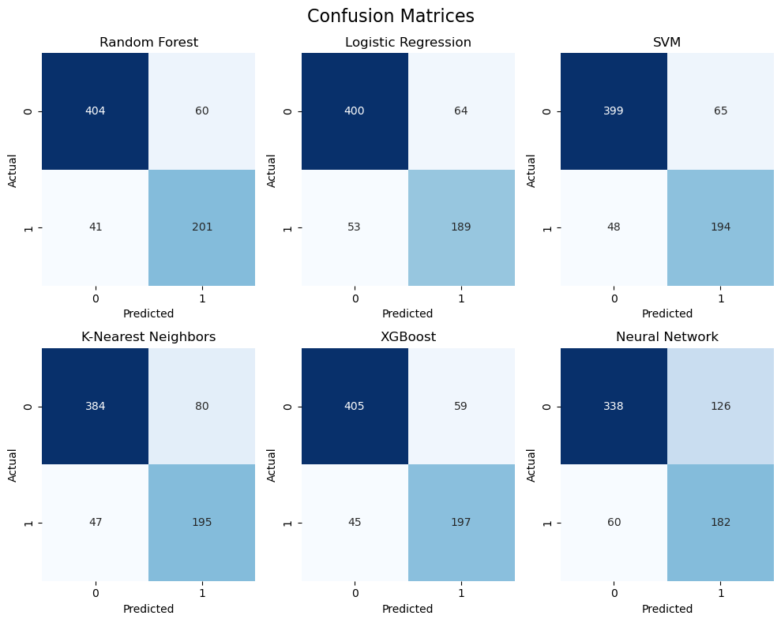

```python
classifier_names = [
    'Random Forest', 'Logistic Regression', 'SVM',
    'K-Nearest Neighbors', 'XGBoost', 'Neural Network'
]

fig, axes = plt.subplots(2, 3, figsize=(10, 8))
fig.suptitle('Confusion Matrices', fontsize=16)

axes = axes.ravel()


for i, (cm, name) in enumerate(zip(
    [cm_rf, cm_lr, cm_svc, cm_knn, cm_xgb, cm_nn],
    classifier_names
)):
    sns.heatmap(cm, annot=True, fmt='d', cmap='Blues', ax=axes[i], cbar=False)
    axes[i].set_title(name)
    axes[i].set_xlabel('Predicted')
    axes[i].set_ylabel('Actual')

plt.tight_layout()
plt.show()
```

Overall the best F1 score is achieved by Random Forest with parameters {'max_depth': None, 'max_features': 'sqrt', 'min_samples_leaf': 2, 'min_samples_split': 5, 'n_estimators': 200}.

We now assess the performance of the same classifiers, but this time trained on a dataset that includes a subset of genes with the highest absolute Spearman correlations, without limiting the selection to target genes.

```python
best_rf = random_forest(X_train_subset, y_train)
y_pred_rf = best_rf.predict(X_test_subset)

accuracy_rf = accuracy_score(y_test, y_pred_rf)
precision_rf = precision_score(y_test, y_pred_rf)
recall_rf = recall_score(y_test, y_pred_rf)
f1_rf = f1_score(y_test, y_pred_rf)
```

```
Fitting 5 folds for each of 216 candidates, totalling 1080 fits
Best Random Forest Parameters: {'max_depth': 10, 'max_features': 'sqrt', 'min_samples_leaf': 1, 'min_samples_split': 2, 'n_estimators': 200}
```

```python
best_lr = logistic_regression(X_train_subset, y_train)
y_pred_lr = best_lr.predict(X_test_subset)

accuracy_lr = accuracy_score(y_test, y_pred_lr)
precision_lr = precision_score(y_test, y_pred_lr)
recall_lr = recall_score(y_test, y_pred_lr)
f1_lr = f1_score(y_test, y_pred_lr)
```

```
Fitting 5 folds for each of 24 candidates, totalling 120 fits
Best Logistic Regression Parameters: {'C': 0.001, 'penalty': 'l1', 'solver': 'liblinear'}
```

```python
best_svc = svm(X_train_subset, y_train)
y_pred_svc = best_svc.predict(X_test_subset)

accuracy_svc = accuracy_score(y_test, y_pred_svc)
precision_svc = precision_score(y_test, y_pred_svc)
recall_svc = recall_score(y_test, y_pred_svc)
f1_svc = f1_score(y_test, y_pred_svc)
```

```
Fitting 5 folds for each of 12 candidates, totalling 60 fits
Best SVM Parameters: {'C': 10, 'gamma': 'scale', 'kernel': 'rbf'}
```

```python
best_knn = knn(X_train_subset, y_train)
y_pred_knn = best_knn.predict(X_test_subset)

accuracy_knn = accuracy_score(y_test, y_pred_knn)
precision_knn = precision_score(y_test, y_pred_knn)
recall_knn = recall_score(y_test, y_pred_knn)
f1_knn = f1_score(y_test, y_pred_knn)
```

```
Fitting 5 folds for each of 30 candidates, totalling 150 fits
Best KNN Parameters: {'metric': 'manhattan', 'n_neighbors': 11, 'weights': 'distance'}
```

```python
best_xgb = xgboost(X_train_subset, y_train)
y_pred_xgb = best_xgb.predict(X_test_subset)

accuracy_xgb = accuracy_score(y_test, y_pred_xgb)
precision_xgb = precision_score(y_test, y_pred_xgb)
recall_xgb = recall_score(y_test, y_pred_xgb)
f1_xgb = f1_score(y_test, y_pred_xgb)
```

```
Fitting 5 folds for each of 32 candidates, totalling 160 fits
Best XGBoost Parameters: {'colsample_bytree': 1.0, 'learning_rate': 0.1, 'max_depth': 3, 'n_estimators': 200, 'subsample': 1.0}
```

```python
best_nn = neural_netw(X_train_subset, y_train)
y_pred_nn = best_nn.predict(X_test_subset)

accuracy_nn = accuracy_score(y_test, y_pred_nn)
precision_nn = precision_score(y_test, y_pred_nn)
recall_nn = recall_score(y_test, y_pred_nn)
f1_nn = f1_score(y_test, y_pred_nn)
```

```
Fitting 5 folds for each of 96 candidates, totalling 480 fits
Best Neural Network Parameters: {'activation': 'tanh', 'alpha': 0.001, 'hidden_layer_sizes': (100, 100), 'learning_rate': 'constant', 'solver': 'adam'}
```

```python
classifiers = [
    ("Random Forest", accuracy_rf, precision_rf, recall_rf, f1_rf),
    ("Logistic Regression", accuracy_lr, precision_lr, recall_lr, f1_lr),
    ("SVM", accuracy_svc, precision_svc, recall_svc, f1_svc),
    ("K-Nearest Neighbors", accuracy_knn, precision_knn, recall_knn, f1_knn),
    ("XGBoost", accuracy_xgb, precision_xgb, recall_xgb, f1_xgb),
    ("Neural Network (MLP)", accuracy_nn, precision_nn, recall_nn, f1_nn)
]

for clf_name, accuracy, precision, recall, f1 in classifiers:
    print(f"{clf_name} Performance:")
    print(f"  Accuracy: {accuracy:.4f} | Precision: {precision:.4f} | Recall: {recall:.4f} | F1 Score: {f1:.4f}\n")
```

```
Random Forest Performance:
  Accuracy: 0.8470 | Precision: 0.7617 | Recall: 0.8058 | F1 Score: 0.7831

Logistic Regression Performance:
  Accuracy: 0.8300 | Precision: 0.7585 | Recall: 0.7397 | F1 Score: 0.7490

SVM Performance:
  Accuracy: 0.8442 | Precision: 0.7683 | Recall: 0.7810 | F1 Score: 0.7746

K-Nearest Neighbors Performance:
  Accuracy: 0.8258 | Precision: 0.7511 | Recall: 0.7355 | F1 Score: 0.7432

XGBoost Performance:
  Accuracy: 0.8499 | Precision: 0.7698 | Recall: 0.8017 | F1 Score: 0.7854

Neural Network (MLP) Performance:
  Accuracy: 0.7989 | Precision: 0.6969 | Recall: 0.7314 | F1 Score: 0.7137
```

```python
cm_rf = confusion_matrix(y_test, y_pred_rf)
cm_lr = confusion_matrix(y_test, y_pred_lr)
cm_svc = confusion_matrix(y_test, y_pred_svc)
cm_knn = confusion_matrix(y_test, y_pred_knn)
cm_xgb = confusion_matrix(y_test, y_pred_xgb)
cm_nn = confusion_matrix(y_test, y_pred_nn)
```

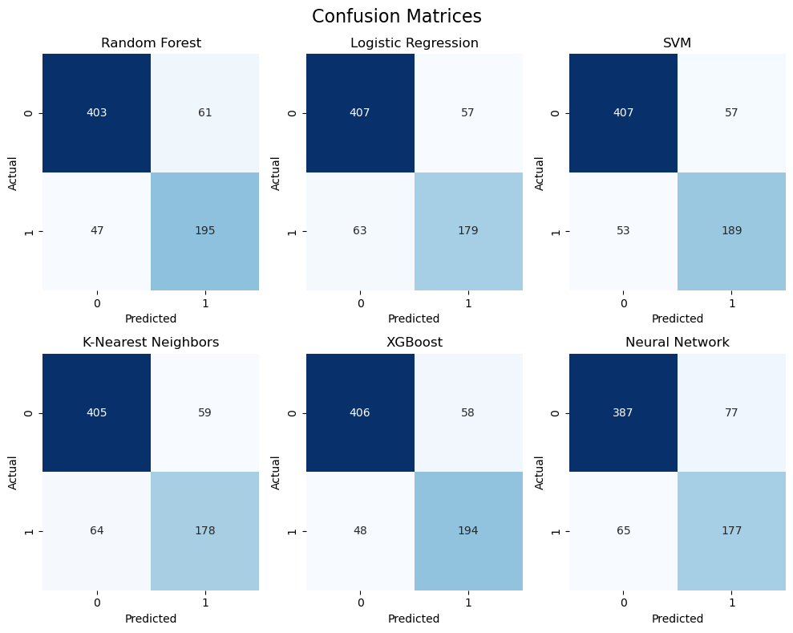

```python
# Classifier names for titles
classifier_names = [
    'Random Forest', 'Logistic Regression', 'SVM',
    'K-Nearest Neighbors', 'XGBoost', 'Neural Network'
]

# Create a figure with subplots
fig, axes = plt.subplots(2, 3, figsize=(10, 8))
fig.suptitle('Confusion Matrices', fontsize=16)

# Flatten axes for easy iteration
axes = axes.ravel()

# Plot each confusion matrix
for i, (cm, name) in enumerate(zip(
    [cm_rf, cm_lr, cm_svc, cm_knn, cm_xgb, cm_nn],
    classifier_names
)):
    sns.heatmap(cm, annot=True, fmt='d', cmap='Blues', ax=axes[i], cbar=False)
    axes[i].set_title(name)
    axes[i].set_xlabel('Predicted')
    axes[i].set_ylabel('Actual')

plt.tight_layout()
plt.show()
```

The performance of the models trained on the top 100 genes—selected based on absolute Spearman correlation without restricting to TP53 target genes—is comparable to that of models trained solely on the TP53 target gene subset. This indicates that the subset of selected target genes is informative and effective for addressing the binary classification task.

The highest overall F1 score is obtained using a Random Forest model trained on the TP53 target gene subset with optimized hyperparameters:  
{'max_depth': None, 'max_features': 'sqrt', 'min_samples_leaf': 2, 'min_samples_split': 5, 'n_estimators': 200}. Performance: Accuracy: 0.8569 | Precision: 0.7701 | Recall: 0.8306 | F1 Score: 0.7992

## Multi-class classifier

We repeat the same procedure, trying now to predict the specific mutation of TP53.

We use the same subsets of genes selected before to make our predictions.

```python
len(mutations['Variant_Type'].unique())
```

```
4
```

```python
y_train = y_train_initial
y_test = y_test_initial
```

```python
print(f"Training data shape: {X_train.shape}")
print(f"Training labels distribution:\n{y_train.value_counts()}")
print()
print(f"Testing data shape: {X_test.shape}")
print(f"Testing labels distribution:\n{y_test.value_counts()}")
```

```
Training data shape: (2823, 17450)
Training labels distribution:
WT     1857
SNP     823
DEL     110
INS      33
Name: Variant_Type, dtype: int64

Testing data shape: (706, 17450)
Testing labels distribution:
WT     464
SNP    206
DEL     28
INS      8
Name: Variant_Type, dtype: int64
```

In this multi-class classification task, the dataset is imbalanced, with some TP53 mutation types being much more common than others. To evaluate model performance fairly, we use average='weighted' for metrics like precision, recall, and F1 score.

This approach calculates the metric for each class and then averages them, weighted by the number of true instances per class. This ensures that more frequent classes have a greater impact on the final score, while still including performance on rare classes.

As before, we begin with the dataset using the subset of target genes as features.

```python
best_rf = random_forest(X_train_target_genes, y_train)
y_pred_rf = best_rf.predict(X_test_target_genes)

accuracy_rf = accuracy_score(y_test, y_pred_rf)
precision_rf = precision_score(y_test, y_pred_rf, average='weighted')
recall_rf = recall_score(y_test, y_pred_rf, average='weighted')
f1_rf = f1_score(y_test, y_pred_rf, average='weighted')
```

```
Fitting 5 folds for each of 216 candidates, totalling 1080 fits
Best Random Forest Parameters: {'max_depth': 10, 'max_features': 'sqrt', 'min_samples_leaf': 4, 'min_samples_split': 2, 'n_estimators': 200}
```

```python
best_lr = logistic_regression(X_train_target_genes, y_train)
y_pred_lr = best_lr.predict(X_test_target_genes)

accuracy_lr = accuracy_score(y_test, y_pred_lr)
precision_lr = precision_score(y_test, y_pred_lr, average='weighted')
recall_lr = recall_score(y_test, y_pred_lr, average='weighted')
f1_lr = f1_score(y_test, y_pred_lr, average='weighted')
```

```
Fitting 5 folds for each of 24 candidates, totalling 120 fits
Best Logistic Regression Parameters: {'C': 0.001, 'penalty': 'l1', 'solver': 'liblinear'}
```

```python
best_svc = svm(X_train_target_genes, y_train)
y_pred_svc = best_svc.predict(X_test_target_genes)

accuracy_svc = accuracy_score(y_test, y_pred_svc)
precision_svc = precision_score(y_test, y_pred_svc, average='weighted')
recall_svc = recall_score(y_test, y_pred_svc, average='weighted')
f1_svc = f1_score(y_test, y_pred_svc, average='weighted')
```

```
Fitting 5 folds for each of 12 candidates, totalling 60 fits
Best SVM Parameters: {'C': 10, 'gamma': 'scale', 'kernel': 'rbf'}
```

```python
best_knn = knn(X_train_target_genes, y_train)
y_pred_knn = best_knn.predict(X_test_target_genes)

accuracy_knn = accuracy_score(y_test, y_pred_knn)
precision_knn = precision_score(y_test, y_pred_knn, average='weighted')
recall_knn = recall_score(y_test, y_pred_knn, average='weighted')
f1_knn = f1_score(y_test, y_pred_knn, average='weighted')
```

```
Fitting 5 folds for each of 30 candidates, totalling 150 fits
Best KNN Parameters: {'metric': 'manhattan', 'n_neighbors': 9, 'weights': 'distance'}
```

```python
from sklearn.preprocessing import LabelEncoder

# XGBoost is expecting numerical labels --> need to convert labels
le = LabelEncoder()
y_train_encoded = le.fit_transform(y_train)
y_test_encoded = le.transform(y_test)


best_xgb = xgboost(X_train_target_genes, y_train_encoded)
y_pred_xgb = best_xgb.predict(X_test_target_genes)

accuracy_xgb = accuracy_score(y_test_encoded, y_pred_xgb)
precision_xgb = precision_score(y_test_encoded, y_pred_xgb, average='weighted')
recall_xgb = recall_score(y_test_encoded, y_pred_xgb, average='weighted')
f1_xgb = f1_score(y_test_encoded, y_pred_xgb, average='weighted')
```

```
Fitting 5 folds for each of 32 candidates, totalling 160 fits
Best XGBoost Parameters: {'colsample_bytree': 0.8, 'learning_rate': 0.1, 'max_depth': 5, 'n_estimators': 200, 'subsample': 0.8}
```

```python
best_nn = neural_netw(X_train_target_genes, y_train)
y_pred_nn = best_nn.predict(X_test_target_genes)

accuracy_nn = accuracy_score(y_test, y_pred_nn)
precision_nn = precision_score(y_test, y_pred_nn, average='weighted')
recall_nn = recall_score(y_test, y_pred_nn, average='weighted')
f1_nn = f1_score(y_test, y_pred_nn, average='weighted')
```

```
Fitting 5 folds for each of 96 candidates, totalling 480 fits
Best Neural Network Parameters: {'activation': 'tanh', 'alpha': 0.01, 'hidden_layer_sizes': (100, 100), 'learning_rate': 'constant', 'solver': 'adam'}
```

```python
classifiers = [
    ("Random Forest", accuracy_rf, precision_rf, recall_rf, f1_rf),
    ("Logistic Regression", accuracy_lr, precision_lr, recall_lr, f1_lr),
    ("SVM", accuracy_svc, precision_svc, recall_svc, f1_svc),
    ("K-Nearest Neighbors", accuracy_knn, precision_knn, recall_knn, f1_knn),
    ("XGBoost", accuracy_xgb, precision_xgb, recall_xgb, f1_xgb),
    ("Neural Network (MLP)", accuracy_nn, precision_nn, recall_nn, f1_nn)
]

for clf_name, accuracy, precision, recall, f1 in classifiers:
    print(f"{clf_name} Performance:")
    print(f"  Accuracy: {accuracy:.4f} | Precision: {precision:.4f} | Recall: {recall:.4f} | F1 Score: {f1:.4f}\n")
```

```
Random Forest Performance:
  Accuracy: 0.8074 | Precision: 0.7727 | Recall: 0.8074 | F1 Score: 0.7889

Logistic Regression Performance:
  Accuracy: 0.7904 | Precision: 0.7599 | Recall: 0.7904 | F1 Score: 0.7744

SVM Performance:
  Accuracy: 0.8017 | Precision: 0.7699 | Recall: 0.8017 | F1 Score: 0.7841

K-Nearest Neighbors Performance:
  Accuracy: 0.7635 | Precision: 0.7408 | Recall: 0.7635 | F1 Score: 0.7500

XGBoost Performance:
  Accuracy: 0.8258 | Precision: 0.7895 | Recall: 0.8258 | F1 Score: 0.8065

Neural Network (MLP) Performance:
  Accuracy: 0.7465 | Precision: 0.7093 | Recall: 0.7465 | F1 Score: 0.7274
```

```python
cm_rf = confusion_matrix(y_test, y_pred_rf)
cm_lr = confusion_matrix(y_test, y_pred_lr)
cm_svc = confusion_matrix(y_test, y_pred_svc)
cm_knn = confusion_matrix(y_test, y_pred_knn)
cm_xgb = confusion_matrix(y_test_encoded, y_pred_xgb)
cm_nn = confusion_matrix(y_test, y_pred_nn)
```

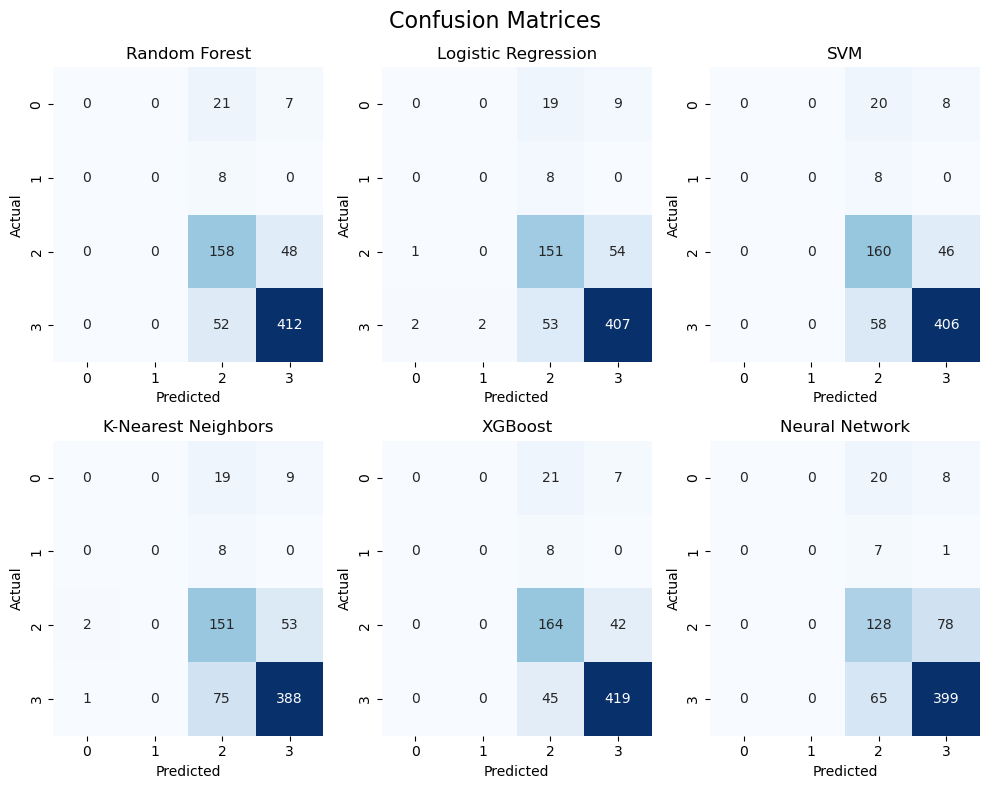

```python
classifier_names = [
    'Random Forest', 'Logistic Regression', 'SVM',
    'K-Nearest Neighbors', 'XGBoost', 'Neural Network'
]

fig, axes = plt.subplots(2, 3, figsize=(10, 8))
fig.suptitle('Confusion Matrices', fontsize=16)

axes = axes.ravel()


for i, (cm, name) in enumerate(zip(
    [cm_rf, cm_lr, cm_svc, cm_knn, cm_xgb, cm_nn],
    classifier_names
)):
    sns.heatmap(cm, annot=True, fmt='d', cmap='Blues', ax=axes[i], cbar=False)
    axes[i].set_title(name)
    axes[i].set_xlabel('Predicted')
    axes[i].set_ylabel('Actual')

plt.tight_layout()
plt.show()
```

Overall the best F1 score is achieved by XGBoost with parameters {'colsample_bytree': 0.8, 'learning_rate': 0.1, 'max_depth': 5, 'n_estimators': 200, 'subsample': 0.8}.

Next, we evaluate performance using the dataset that uses the full gene subset as features.

```python
best_rf = random_forest(X_train_subset, y_train)
y_pred_rf = best_rf.predict(X_test_subset)

accuracy_rf = accuracy_score(y_test, y_pred_rf)
precision_rf = precision_score(y_test, y_pred_rf, average='weighted')
recall_rf = recall_score(y_test, y_pred_rf, average='weighted')
f1_rf = f1_score(y_test, y_pred_rf, average='weighted')
```

```
Fitting 5 folds for each of 216 candidates, totalling 1080 fits
Best Random Forest Parameters: {'max_depth': 20, 'max_features': 'sqrt', 'min_samples_leaf': 2, 'min_samples_split': 5, 'n_estimators': 50}
```

```python
best_lr = logistic_regression(X_train_subset, y_train)
y_pred_lr = best_lr.predict(X_test_subset)

accuracy_lr = accuracy_score(y_test, y_pred_lr)
precision_lr = precision_score(y_test, y_pred_lr, average='weighted')
recall_lr = recall_score(y_test, y_pred_lr, average='weighted')
f1_lr = f1_score(y_test, y_pred_lr, average='weighted')
```

```
Fitting 5 folds for each of 24 candidates, totalling 120 fits
Best Logistic Regression Parameters: {'C': 0.001, 'penalty': 'l1', 'solver': 'saga'}
```

```python
best_svc = svm(X_train_subset, y_train)
y_pred_svc = best_svc.predict(X_test_subset)

accuracy_svc = accuracy_score(y_test, y_pred_svc)
precision_svc = precision_score(y_test, y_pred_svc, average='weighted')
recall_svc = recall_score(y_test, y_pred_svc, average='weighted')
f1_svc = f1_score(y_test, y_pred_svc, average='weighted')
```

```
Fitting 5 folds for each of 12 candidates, totalling 60 fits
Best SVM Parameters: {'C': 10, 'gamma': 'scale', 'kernel': 'rbf'}
```

```python
best_knn = knn(X_train_subset, y_train)
y_pred_knn = best_knn.predict(X_test_subset)

accuracy_knn = accuracy_score(y_test, y_pred_knn)
precision_knn = precision_score(y_test, y_pred_knn, average='weighted')
recall_knn = recall_score(y_test, y_pred_knn, average='weighted')
f1_knn = f1_score(y_test, y_pred_knn, average='weighted')
```

```
Fitting 5 folds for each of 30 candidates, totalling 150 fits
Best KNN Parameters: {'metric': 'manhattan', 'n_neighbors': 11, 'weights': 'uniform'}
```

```python
best_xgb = xgboost(X_train_subset, y_train_encoded)
y_pred_xgb = best_xgb.predict(X_test_subset)

accuracy_xgb = accuracy_score(y_test_encoded, y_pred_xgb)
precision_xgb = precision_score(y_test_encoded, y_pred_xgb, average='weighted')
recall_xgb = recall_score(y_test_encoded, y_pred_xgb, average='weighted')
f1_xgb = f1_score(y_test_encoded, y_pred_xgb, average='weighted')
```

```
Fitting 5 folds for each of 32 candidates, totalling 160 fits
Best XGBoost Parameters: {'colsample_bytree': 0.8, 'learning_rate': 0.1, 'max_depth': 3, 'n_estimators': 100, 'subsample': 1.0}
```

```python
best_nn = neural_netw(X_train_subset, y_train)
y_pred_nn = best_nn.predict(X_test_subset)

accuracy_nn = accuracy_score(y_test, y_pred_nn)
precision_nn = precision_score(y_test, y_pred_nn, average='weighted')
recall_nn = recall_score(y_test, y_pred_nn, average='weighted')
f1_nn = f1_score(y_test, y_pred_nn, average='weighted')
```

```
Fitting 5 folds for each of 96 candidates, totalling 480 fits
Best Neural Network Parameters: {'activation': 'tanh', 'alpha': 0.01, 'hidden_layer_sizes': (100, 50), 'learning_rate': 'constant', 'solver': 'adam'}
```

```python
classifiers = [
    ("Random Forest", accuracy_rf, precision_rf, recall_rf, f1_rf),
    ("Logistic Regression", accuracy_lr, precision_lr, recall_lr, f1_lr),
    ("SVM", accuracy_svc, precision_svc, recall_svc, f1_svc),
    ("K-Nearest Neighbors", accuracy_knn, precision_knn, recall_knn, f1_knn),
    ("XGBoost", accuracy_xgb, precision_xgb, recall_xgb, f1_xgb),
    ("Neural Network (MLP)", accuracy_nn, precision_nn, recall_nn, f1_nn)
]

for clf_name, accuracy, precision, recall, f1 in classifiers:
    print(f"{clf_name} Performance:")
    print(f"  Accuracy: {accuracy:.4f} | Precision: {precision:.4f} | Recall: {recall:.4f} | F1 Score: {f1:.4f}\n")
```

```
Random Forest Performance:
  Accuracy: 0.8116 | Precision: 0.7759 | Recall: 0.8116 | F1 Score: 0.7927

Logistic Regression Performance:
  Accuracy: 0.7946 | Precision: 0.7567 | Recall: 0.7946 | F1 Score: 0.7752

SVM Performance:
  Accuracy: 0.8031 | Precision: 0.7800 | Recall: 0.8031 | F1 Score: 0.7876

K-Nearest Neighbors Performance:
  Accuracy: 0.7790 | Precision: 0.7427 | Recall: 0.7790 | F1 Score: 0.7603

XGBoost Performance:
  Accuracy: 0.8130 | Precision: 0.7793 | Recall: 0.8130 | F1 Score: 0.7949

Neural Network (MLP) Performance:
  Accuracy: 0.7635 | Precision: 0.7176 | Recall: 0.7635 | F1 Score: 0.7384
```

```python
cm_rf = confusion_matrix(y_test, y_pred_rf)
cm_lr = confusion_matrix(y_test, y_pred_lr)
cm_svc = confusion_matrix(y_test, y_pred_svc)
cm_knn = confusion_matrix(y_test, y_pred_knn)
cm_xgb = confusion_matrix(y_test_encoded, y_pred_xgb)
cm_nn = confusion_matrix(y_test, y_pred_nn)
```

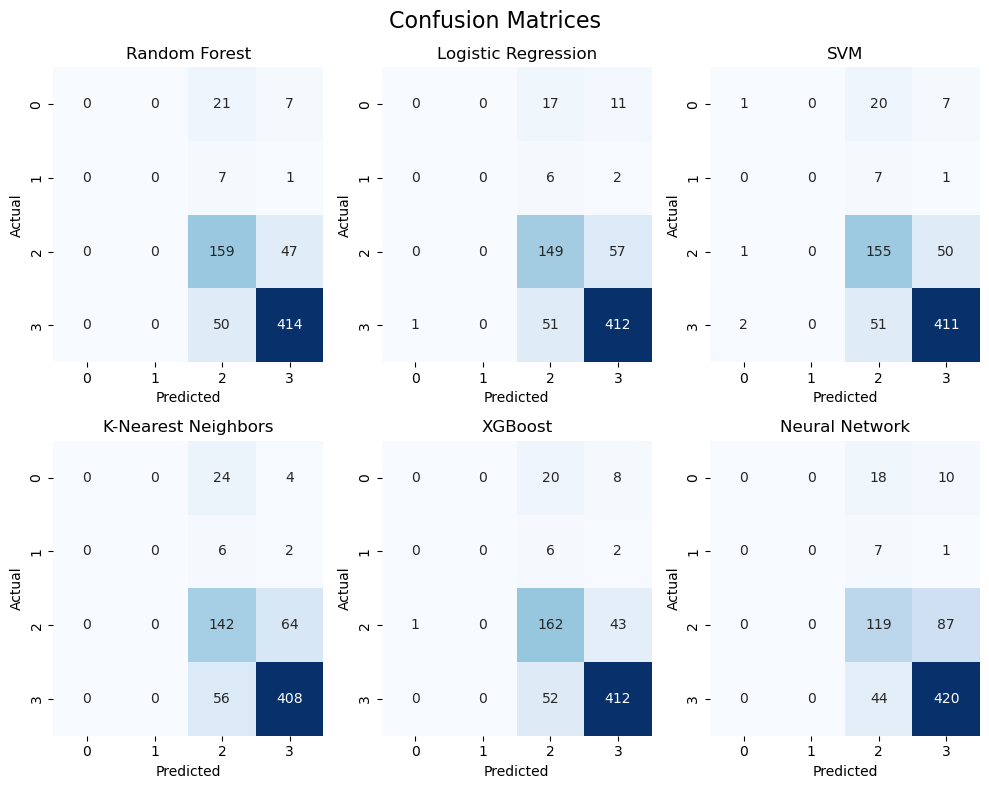

```python
classifier_names = [
    'Random Forest', 'Logistic Regression', 'SVM',
    'K-Nearest Neighbors', 'XGBoost', 'Neural Network'
]

fig, axes = plt.subplots(2, 3, figsize=(10, 8))
fig.suptitle('Confusion Matrices', fontsize=16)

axes = axes.ravel()


for i, (cm, name) in enumerate(zip(
    [cm_rf, cm_lr, cm_svc, cm_knn, cm_xgb, cm_nn],
    classifier_names
)):
    sns.heatmap(cm, annot=True, fmt='d', cmap='Blues', ax=axes[i], cbar=False)
    axes[i].set_title(name)
    axes[i].set_xlabel('Predicted')
    axes[i].set_ylabel('Actual')

plt.tight_layout()
plt.show()
```